# Dimensionality reduction techniques

## The Data

The dataset originates from the United Nations Development Programme. The data has been mutated and now it contains 155 observations and 8 variables in the dataset. The variables in the dataset are listed below.

```r
setwd("C:/Users/Severi/Documents/Open Data/IODS-project/data")
library(MASS)
library(dplyr)
library('corrplot')
library(GGally)
library(tidyr)
library(ggplot2)
human_ <- read.table(file = "human2.txt", sep = ";")
```

```r
str(human_)
```

```
## 'data.frame':    155 obs. of  8 variables:
##  $ edu2FM   : num  1.007 0.997 0.983 0.989 0.969 ...
##  $ labF     : num  61.2 58.8 61.8 58.7 58.5 53.6 53.1 56.3 61.6 62 ...
##  $ lifeexp  : num  81.6 82.4 83 80.2 81.6 80.9 80.9 79.1 82 81.8 ...
##  $ eduexp   : num  17.5 20.2 15.8 18.7 17.9 16.5 18.6 16.5 15.9 19.2 ...
##  $ gni      : int  64992 42261 56431 44025 45435 43919 39568 52947 42155 32689 ...
##  $ matmort  : int  4 6 6 5 6 7 9 28 11 8 ...
##  $ adolbirth: num  7.8 12.1 1.9 5.1 6.2 3.8 8.2 31 14.5 25.3 ...
##  $ repparl  : num  39.6 30.5 28.5 38 36.9 36.9 19.9 19.4 28.2 31.4 ...
```

```r
dim(human_)
```

```
## [1] 155   8
```

- *edu2FM* - Female/male ratio in secondary education
- *labF* - Proportion of females in the labour force
- *lifeexp* - Life expectancy at birth
- *eduexp* - Expected years of schooling
- *gni* - Gross National Income per capita
- *matmort* - Maternal mortality ratio
- *adolbirth* - Adolescent birth rate
- *repparl* - Percetange of female representatives in parliament

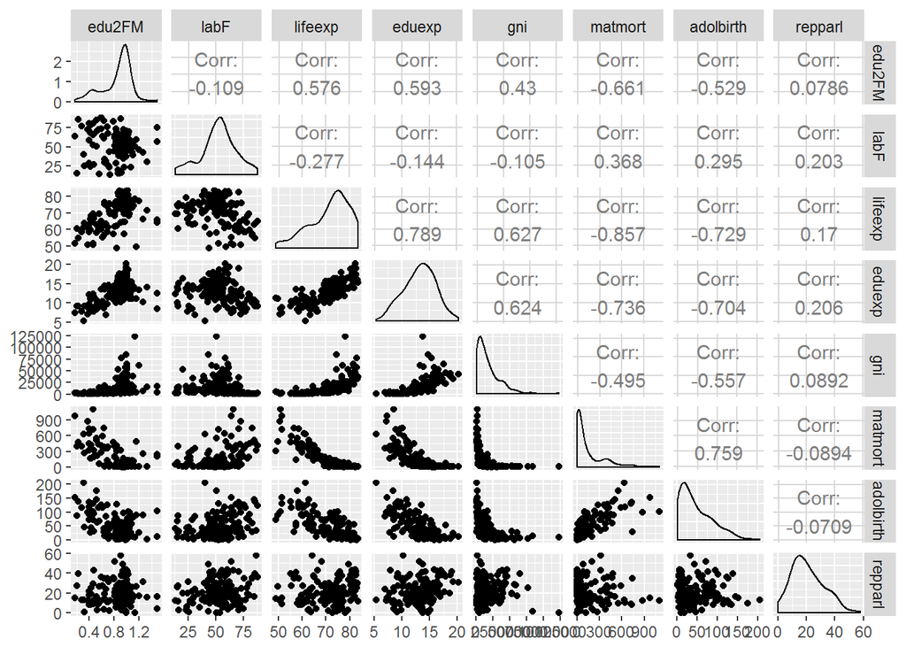

```r
ggpairs(human_)
```

The correlation plot shows strong negative correlation between the previously mentioned variables: *lifeexp* and *matmort*. Also strong negative correlation is between *lifeexp*-*adolbirth*, *eduexp*-*matmort*, and *eduexp*-*adolbirth*. Strong positive correlation is noticable between *lifeexp*-*eduexp* and *marmort*-*adolbirth*.

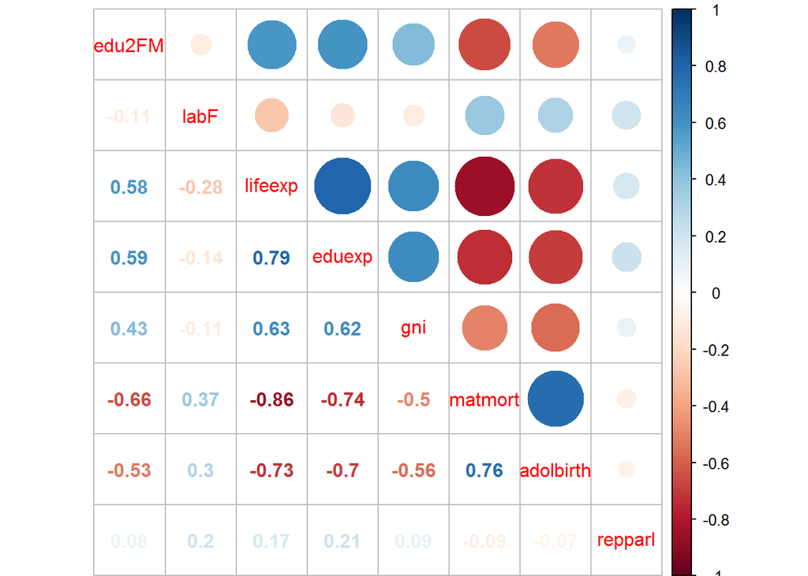

```r
cor_matrix<-cor(human_) %>% round(digits = 2)
corrplot.mixed(cor_matrix)
```

The summaries of the variables are below. The female/male ratio in secondary education (*edu2FM*) on average is about 0.85. Proportion of females in the labour force (*labF*) ranges from 13.5 to 88.1 with average of 52.5. Gross National Income per capita (*gni*) range is really big (from 581 to 123124). Interestingly, our data shows that some Parliaments have no women representatives.

```r
summary(human_)
```

```
##      edu2FM            labF          lifeexp          eduexp
##  Min.   :0.1717   Min.   :13.50   Min.   :49.00   Min.   : 5.40
##  1st Qu.:0.7264   1st Qu.:44.45   1st Qu.:66.30   1st Qu.:11.25
##  Median :0.9375   Median :53.50   Median :74.20   Median :13.50
##  Mean   :0.8529   Mean   :52.52   Mean   :71.65   Mean   :13.18
##  3rd Qu.:0.9968   3rd Qu.:61.90   3rd Qu.:77.25   3rd Qu.:15.20
##  Max.   :1.4967   Max.   :88.10   Max.   :83.50   Max.   :20.20
##       gni            matmort         adolbirth         repparl
##  Min.   :   581   Min.   :   1.0   Min.   :  0.60   Min.   : 0.00
##  1st Qu.:  4198   1st Qu.:  11.5   1st Qu.: 12.65   1st Qu.:12.40
##  Median : 12040   Median :  49.0   Median : 33.60   Median :19.30
##  Mean   : 17628   Mean   : 149.1   Mean   : 47.16   Mean   :20.91
##  3rd Qu.: 24512   3rd Qu.: 190.0   3rd Qu.: 71.95   3rd Qu.:27.95
##  Max.   :123124   Max.   :1100.0   Max.   :204.80   Max.   :57.50
```

## Principal Component Analysis (PCA)

```r
pca_human <- prcomp(human_)
summary(pca_human)
```

```
## Importance of components:
##                              PC1      PC2   PC3   PC4   PC5   PC6   PC7
## Standard deviation     1.854e+04 185.6147 25.21 15.38 10.68 3.766 1.546
## Proportion of Variance 9.999e-01   0.0001  0.00  0.00  0.00 0.000 0.000
## Cumulative Proportion  9.999e-01   1.0000  1.00  1.00  1.00 1.000 1.000
##                           PC8
## Standard deviation     0.1734
## Proportion of Variance 0.0000
## Cumulative Proportion  1.0000
```

The same goes for the biplot below which clearly indicates that *gni* has much bigger scale than all the other variables.

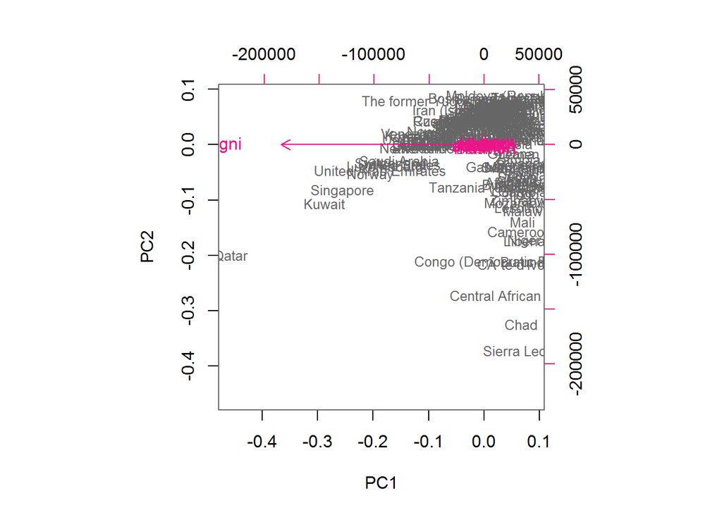

```r
biplot(pca_human, choices = 1:2, cex = c(0.8, 1), col = c("grey40", "deeppink2"))
```

The data will, therefore, be standartized.

The summary of variables now shows that the scale is now more similar between different variables, thus the PCA can now be performed again.

```r
human_std <- scale(human_)
summary(human_std)
```

```
##      edu2FM             labF             lifeexp            eduexp
##  Min.   :-2.8189   Min.   :-2.43186   Min.   :-2.7188   Min.   :-2.7378
##  1st Qu.:-0.5233   1st Qu.:-0.50289   1st Qu.:-0.6425   1st Qu.:-0.6782
##  Median : 0.3503   Median : 0.06116   Median : 0.3056   Median : 0.1140
##  Mean   : 0.0000   Mean   : 0.00000   Mean   : 0.0000   Mean   : 0.0000
##  3rd Qu.: 0.5958   3rd Qu.: 0.58469   3rd Qu.: 0.6717   3rd Qu.: 0.7126
##  Max.   : 2.6646   Max.   : 2.21762   Max.   : 1.4218   Max.   : 2.4730
##       gni             matmort          adolbirth          repparl
##  Min.   :-0.9193   Min.   :-0.6992   Min.   :-1.1325   Min.   :-1.8203
##  1st Qu.:-0.7243   1st Qu.:-0.6496   1st Qu.:-0.8394   1st Qu.:-0.7409
##  Median :-0.3013   Median :-0.4726   Median :-0.3298   Median :-0.1403
##  Mean   : 0.0000   Mean   : 0.0000   Mean   : 0.0000   Mean   : 0.0000
##  3rd Qu.: 0.3712   3rd Qu.: 0.1932   3rd Qu.: 0.6030   3rd Qu.: 0.6127
##  Max.   : 5.6890   Max.   : 4.4899   Max.   : 3.8344   Max.   : 3.1850
```

The summary shows that now 2 first components explain about 70% of variance, thus the results of the PCA are much better after the data has been standartized.

```r
pca_human2 <- prcomp(human_std)
summary(pca_human2)
```

```
## Importance of components:
##                           PC1    PC2     PC3     PC4     PC5     PC6
## Standard deviation     2.0884 1.1132 0.87196 0.77712 0.64106 0.53726
## Proportion of Variance 0.5452 0.1549 0.09504 0.07549 0.05137 0.03608
## Cumulative Proportion  0.5452 0.7001 0.79512 0.87061 0.92198 0.95806
##                           PC7     PC8
## Standard deviation     0.4800 0.32430
## Proportion of Variance 0.0288 0.01315
## Cumulative Proportion  0.9869 1.00000
```

The biplot shows high correlation between *matmort* and *adolbirth*. In addition to that the variables *gni*, *eduexp*, *edu2FM* and *lifeexp* seems to be correlated with each other as well. *repparl* is mostly correlated with *labF*; other variables have low/no correlation with *repparl*.

It looks like *matmort*, *adolbirth*, *gni*, *eduexp*, *edu2FM* and *lifeexp* contribute to the dimension of the PC1, while *repparl* and *labF* best define PC2.

The variables that define PC1 are clearly devided into two groups.One group of variables consists of *eduexp* (expected years of schooling), *gni* (Gross National Income per capita), *edu2FM* (female/male ratio in secondary education), and *lifeexp* (life expectancy at birth). The other group defining PC1 contains *matmort* (maternal mortality ratio) and *adolbirth* (adolescent birth rate). These groups together explain education, health and general wealth phenomenons.

The second principal component that is defined by *repparl* (percentage of female representatives in the parliament) and *labF* (proportion of females in the labour force) explains the gender diversity phenomenon.

The plot indicates that such countries as, e.g. Iceland, Norway, Sweden, Denmank have not only high gross national income per capita but also are high in gender diversity and life expentancy. Whereas, Saudi Arabia, Qatar, Bahrain are high in GNI, but don’t have a good situation in gender diversity issues. Countries in Africa seem to have high mortality, poor education and low income.

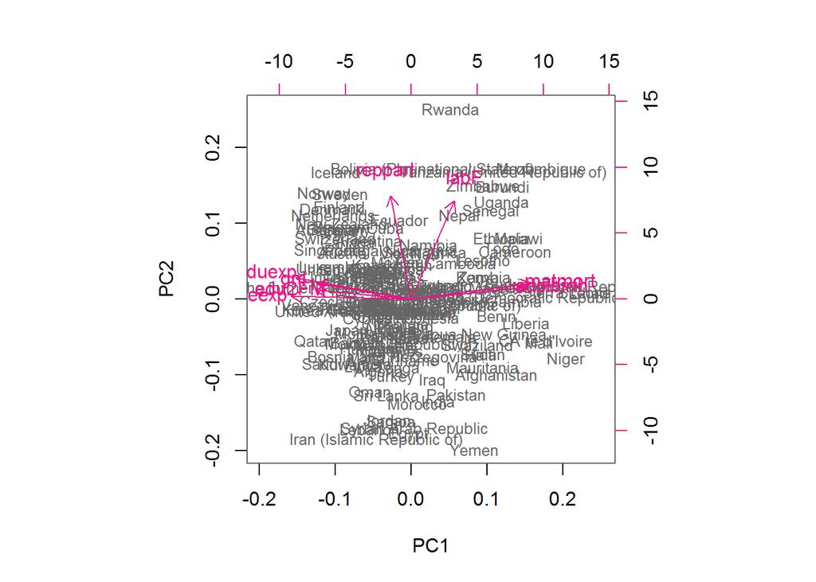

```r
biplot(pca_human2, choices = 1:2, cex = c(0.8, 1), col = c("grey40", "deeppink2"))
```

## Tea dataset

New dataset is now loaded. It is related to tea consumption. The data has 300 observations and 36 variables.

```r
library(FactoMineR)
data("tea")
dim(tea)
```

```
## [1] 300  36
```

It seems that the variables are related to the time people drink their tea, the places where they drink, how and why they drink it and some other information.

```r
str(tea)
```

```
## 'data.frame':    300 obs. of  36 variables:
##  $ breakfast       : Factor w/ 2 levels "breakfast","Not.breakfast": 1 1 2 2 1 2 1 2 1 1 ...
##  $ tea.time        : Factor w/ 2 levels "Not.tea time",..: 1 1 2 1 1 1 2 2 2 1 ...
##  $ evening         : Factor w/ 2 levels "evening","Not.evening": 2 2 1 2 1 2 2 1 2 1 ...
##  $ lunch           : Factor w/ 2 levels "lunch","Not.lunch": 2 2 2 2 2 2 2 2 2 2 ...
##  $ dinner          : Factor w/ 2 levels "dinner","Not.dinner": 2 2 1 1 2 1 2 2 2 2 ...
##  $ always          : Factor w/ 2 levels "always","Not.always": 2 2 2 2 1 2 2 2 2 2 ...
##  $ home            : Factor w/ 2 levels "home","Not.home": 1 1 1 1 1 1 1 1 1 1 ...
##  $ work            : Factor w/ 2 levels "Not.work","work": 1 1 2 1 1 1 1 1 1 1 ...
##  $ tearoom         : Factor w/ 2 levels "Not.tearoom",..: 1 1 1 1 1 1 1 1 1 2 ...
##  $ friends         : Factor w/ 2 levels "friends","Not.friends": 2 2 1 2 2 2 1 2 2 2 ...
##  $ resto           : Factor w/ 2 levels "Not.resto","resto": 1 1 2 1 1 1 1 1 1 1 ...
##  $ pub             : Factor w/ 2 levels "Not.pub","pub": 1 1 1 1 1 1 1 1 1 1 ...
##  $ Tea             : Factor w/ 3 levels "black","Earl Grey",..: 1 1 2 2 2 2 2 1 2 1 ...
##  $ How             : Factor w/ 4 levels "alone","lemon",..: 1 3 1 1 1 1 1 3 3 1 ...
```

[output cut: 22 more lines]

Only the variables realted to type of tea, way of drinking, frequency of drinking tea and wheather or not tea drinking is feminine or spiritual will be analysed. Their summaries are below.

```r
keep_columns <- c("Tea", "How", "how", "feminine", "frequency", "spirituality")
tea_time <- dplyr::select(tea, one_of(keep_columns))
summary(tea_time)
```

```
##         Tea         How                      how              feminine
##  black    : 74   alone:195   tea bag           :170   feminine    :129
##  Earl Grey:193   lemon: 33   tea bag+unpackaged: 94   Not.feminine:171
##  green    : 33   milk : 63   unpackaged        : 36
##                  other:  9
##        frequency             spirituality
##  1/day      : 95   Not.spirituality:206
##  1 to 2/week: 44   spirituality    : 94
##  +2/day     :127
##  3 to 6/week: 34
```

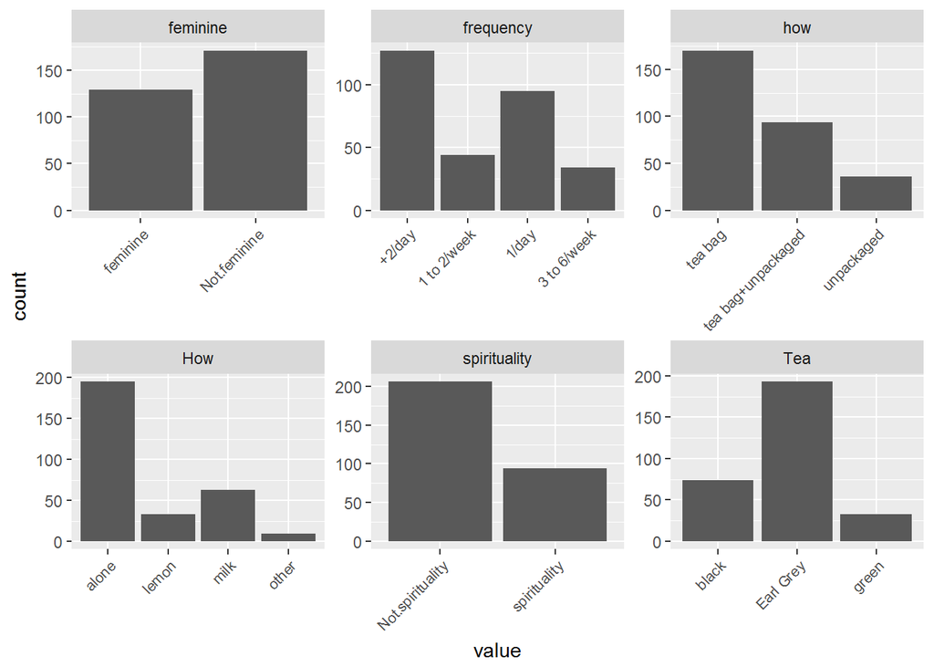

```r
gather(tea_time) %>% ggplot(aes(value)) + facet_wrap("key", scales = "free") + geom_bar() + theme(axis.text.x = element_text(angle = 45, hjust = 1, size = 8))
```

There are 12 dimensions based on the summary below.

```r
mca <- MCA(tea_time, graph = FALSE)
summary(mca)
```

```
##
## Call:
## MCA(X = tea_time, graph = FALSE)
##
##
## Eigenvalues
##                        Dim.1   Dim.2   Dim.3   Dim.4   Dim.5   Dim.6
## Variance               0.222   0.210   0.200   0.193   0.179   0.168
## % of var.             11.096  10.509  10.001   9.640   8.973   8.402
## Cumulative % of var.  11.096  21.605  31.605  41.245  50.218  58.620
##                        Dim.7   Dim.8   Dim.9  Dim.10  Dim.11  Dim.12
## Variance               0.165   0.159   0.143   0.138   0.112   0.111
## % of var.              8.253   7.953   7.156   6.904   5.586   5.528
## Cumulative % of var.  66.873  74.826  81.982  88.886  94.472 100.000
##
## Individuals (the 10 first)
##                       Dim.1    ctr   cos2    Dim.2    ctr   cos2    Dim.3
## 1                  |  0.247  0.092  0.047 | -0.717  0.815  0.399 | -0.202
## 2                  |  0.161  0.039  0.014 | -1.130  2.027  0.700 |  0.153
## 3                  | -0.041  0.002  0.002 | -0.085  0.011  0.010 | -0.040
## 4                  | -0.615  0.567  0.326 | -0.198  0.062  0.034 | -0.044
## 5                  | -0.291  0.127  0.082 |  0.267  0.113  0.069 |  0.177
## 6                  | -0.364  0.199  0.152 | -0.549  0.478  0.346 | -0.261
## 7                  |  0.062  0.006  0.002 | -0.113  0.020  0.007 | -0.565
## 8                  |  0.161  0.039  0.010 | -0.289  0.133  0.033 | -0.038
## 9                  |  0.100  0.015  0.007 | -0.383  0.232  0.097 |  0.588
## 10                 |  0.798  0.957  0.457 | -0.137  0.030  0.013 |  0.292
##                       ctr   cos2
## 1                   0.068  0.032 |
## 2                   0.039  0.013 |
## 3                   0.003  0.002 |
## 4                   0.003  0.002 |
## 5                   0.052  0.030 |
## 6                   0.114  0.078 |
## 7                   0.532  0.176 |
## 8                   0.002  0.001 |
## 9                   0.575  0.228 |
## 10                  0.142  0.061 |
##
## Categories (the 10 first)
```

[output cut: 16 more lines]

```
## lemon                0.114   5.836 |   0.236   0.513   0.007   1.438 |
## milk                 0.252  -8.688 |   0.596   6.217   0.094   5.314 |
## other                0.002  -0.722 |   2.678  17.926   0.222   8.143 |
## tea bag              0.053  -3.974 |  -0.090   0.386   0.011  -1.787 |
## tea bag+unpackaged   0.006   1.367 |   0.641  10.734   0.188   7.489 |
## unpackaged           0.056   4.108 |  -1.247  15.561   0.212  -7.966 |
##
## Categorical variables (eta2)
##                      Dim.1 Dim.2 Dim.3
## Tea                | 0.536 0.041 0.116 |
## How                | 0.138 0.320 0.378 |
## how                | 0.310 0.077 0.320 |
## feminine           | 0.036 0.279 0.012 |
## frequency          | 0.204 0.343 0.301 |
## spirituality       | 0.108 0.201 0.073 |
```

The MCA factor map shows that people who preffer drinking tea alone, like it to be Earl Grey or green. It seems that those who view tea drinking as non spiritual also think it’s not a feminine activity, while those who associate it with femininity also think it’s spiritual.

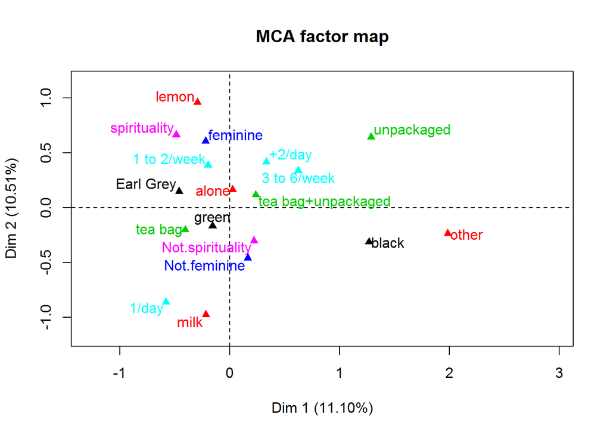

```r
plot(mca, invisible = c("ind"), habillage = "quali")
```